# House Prices Prediction Algorithm

## Steps in CRISP-DM (Cross Industry Standard Process for Data Mining )

Step 1: Understand the Business Objective/Question  
Step 2: Data Understanding  
Step 3: Data Preparation  
Step 4: Modeling  
Step 5: Evaluation  
Step 6: Deployment

# Step 1: Understand the Business Question

This regression model and those like it that predict house prices can be used in conjunction with real estate businesses to better understand the underlying worth of a home. Consumers can also use this tool to better understand what features of a house most factor in to increased prices.

# Step 2: Data Understanding

This data set was collected from real homes in Ames Iowa, and was taken from the kaggle website. The goal of this algorithm is to use the train data set to create and fit a model that will then predict the house prices for the test data set. This algorithm is a part of the kaggle competition for house prices, and thus the test dataset does not include house prices. Thus, we must use one data set to predict house prices for the other data set.

## **Data Dictionary**

### **Dependent Variable**

**Sale Price:** **Numeric variable**  
the property's sale price in dollars

### **Independent Variables**

**MSSubClass:** **Categorical variable**  
The type/classification of home being sold  
**MSZoning:** **Categorical variable**  
The general zoning classification  
**LotFrontage:** **Numeric variable**  
Linear feet of street connected to property  
**LotArea:** **Numeric variable**  
Lot size in square feet  
**Street:** **Categorical variable**  
Type of road access to property  
**Alley:** **Categorical variable**  
Type of alley access  
**LotShape:** **Categorical variable**  
Overall shape of property  
**LandContour :** **Categorical variable**  
Grade of the property  
**Utilities :** **Categorical variable**  
Type of utilities available  
**LotConfig :** **Categorical variable**  
Lot configuration  
**LandSlope :** **Categorical variable**  
Slope of property  
**Neighborhood :** **Categorical variable**  
rPhysical locations within Ames city limits  
**Condition1 :** **Categorical variable**  
Proximity to main road or railroad  
**Condition2 :** **Categorical variable**  
Proximity to main road or railroad (if a second is present)  
**BldgType :** **Categorical variable**  
Type of dwelling  
**HouseStyle :** **Categorical variable**  
Style of dwelling  
**OverallQual :** **Ordinal variable**  
Overall material and finish quality  
**OverallCond :** **Ordinal variable**  
Overall condition rating  
**YearBuilt: :** **Numeric variable**  
Original construction date  
**YearRemodAdd :** **Numeric variable**  
Date remodeled  
**RoofStyle :** **Categorical variable**  
Type of roof  
**RoofMatl :** **Categorical variable**  
Material roof is made of  
**Exterior1st :** **Categorical variable**  
Exterior material covering on house  
**Exterior2nd :** **Categorical variable**  
Exterior material covering on house (if more than one material)  
**MasVnrType :** **Categorical variable**  
Masonry veneer type  
**MasVnrArea :** **Numeric variable**  
Masonry veneer area in square feet  
**ExterQual :** **Ordinal variable**  
Exterior material quality  
**ExterCond :** **Ordinal variable**  
Present condition of the material on the exterior  
**Foundation :** **Categorical variable**  
Type of Foundation  
**BsmtQual :** **Ordinal variable**  
Quality of the basement  
**BsmtCond :** **Ordinal variable**  
Present condition of the basement  
**BsmtExposure :** **Categorical variable**  
Walkout or garden level basement walls  
**BsmtFinType1 :** **Categorical variable**  
Quality of basement finished area  
**BsmtFinSF1 :** **Numeric variable**  
Type 1 finished square feet  
**BsmtFinType2: :** **Categorical variable**  
Quality of second finished area (if present)  
**BsmtFinSF2 :** **Numeric variable**  
Type 2 finished square feet  
**BsmtUnfSF :** **Numeric variable**  
Unfinished square feet of basement area  
**TotalBsmtSF :** **Numeric variable**  
Total square feet of basement area  
**Heating :** **Categorical variable**  
Type of heating  
**HeatingQC :** **Ordinal variable**  
Heating quality and condition  
**CentralAir :** **Categorical variable**  
Central air conditioning  
**Electrical :** **Categorical variable**  
Electrical system used in house  
**1stFlrSF :** **Numeric variable**  
First floor square feet

**2ndFlrSF :****Numeric variable**  
Second floor square feet  
**LowQualFinSF :****Numeric variable**  
Low quality finished square feet (all floors)  
**GrLivArea :****Numeric variable**  
Above grade (ground) living area square feet  
**BsmtFullBath :****Numeric variable**  
Basement full bathrooms  
**BsmtHalfBath : ****Numeric variable**  
Basement half bathrooms  
**FullBath : ****Numeric variable**  
Full bathrooms above grade  
**HalfBath : ****Numeric variable**  
Half baths above grade  
**Bedroom : ****Numeric variable**  
Number of bedrooms above basement level  
**Kitchen : ****Numeric variable**  
Number of kitchens  
**KitchenQual : ****Ordinal variable**  
Kitchen quality  
**TotRmsAbvGrd : ****Numeric variable**  
Total rooms above grade (does not include bathrooms)  
**Functional : ****Categorical variable**  
Home functionality rating  
**Fireplaces : ****Numeric variable**  
Number of fireplaces  
**FireplaceQu : ****Ordinal variable**  
Fireplace quality  
**GarageType : ****Categorical variable**  
Garage location  
**GarageYrBlt : ****Numeric variable**  
Year garage was built  
**GarageFinish : ****Categorical variable**  
Interior finish of the garage  
**GarageCars: ****Numeric variable**  
Size of garage in car capacity  
**GarageArea : ****Numeric variable**  
Size of garage in square feet  
**GarageQual : ****Ordinal variable**  
Garage quality  
**GarageCond : ****Ordinal variable**  
Garage condition  
**PavedDrive : ****Categorical variable**  
Paved driveway  
**WoodDeckSF : ****Numeric variable**  
Wood deck area in square feet  
**OpenPorchSF : ****Numeric variable**  
Open porch area in square feet  
**EnclosedPorch : ****Numeric variable**  
Enclosed porch area in square feet  
**3SsnPorch : ****Numeric variable**  
Three season porch area in square feet  
**ScreenPorch : ****Numeric variable**  
Screen porch area in square feet  
**PoolArea : ****Numeric variable**  
Pool area in square feet  
**PoolQC : ****Ordinal variable**  
Pool quality  
**Fence :****Ordinal variable**  
Fence quality  
**MiscFeature : ****Categorical variable**  
Miscellaneous feature not covered in other categories  
**MiscVal : ****Numeric variable**  
Dollar value of miscellaneous feature  
**MoSold : ** **Numeric variable**  
Month Sold  
**YrSold :** **Numeric variable**  
Year Sold  
**SaleType :** **Categorical variable**  
Type of sale  
** SaleCondition :** **Categorical variable**  
Condition of sale

### **Descriptive Variables**

**ID:** Used to identify a specific house

# Step 3: Data Preperation

## Begin by Downloading necessary libraries and reading necessary files into Data frames

```python
import pandas as pd # used for working with dataframes
import numpy as np # used for function on dataframes
import matplotlib.pyplot as plt # used for grpahing
import seaborn as sns # used to make graphs presentable
%matplotlib inline
from scipy import stats

train=pd.read_csv('train.csv')
test=pd.read_csv('test.csv')
```

Check for Null values in the train data set

```python
train.info()
```

```
<class 'pandas.core.frame.DataFrame'>
RangeIndex: 1460 entries, 0 to 1459
Data columns (total 81 columns):
Id               1460 non-null int64
MSSubClass       1460 non-null int64
MSZoning         1460 non-null object
LotFrontage      1201 non-null float64
LotArea          1460 non-null int64
Street           1460 non-null object
Alley            91 non-null object
LotShape         1460 non-null object
LandContour      1460 non-null object
Utilities        1460 non-null object
LotConfig        1460 non-null object
LandSlope        1460 non-null object
Neighborhood     1460 non-null object
Condition1       1460 non-null object
Condition2       1460 non-null object
BldgType         1460 non-null object
HouseStyle       1460 non-null object
OverallQual      1460 non-null int64
OverallCond      1460 non-null int64
YearBuilt        1460 non-null int64
YearRemodAdd     1460 non-null int64
RoofStyle        1460 non-null object
RoofMatl         1460 non-null object
Exterior1st      1460 non-null object
Exterior2nd      1460 non-null object
MasVnrType       1452 non-null object
MasVnrArea       1452 non-null float64
ExterQual        1460 non-null object
ExterCond        1460 non-null object
Foundation       1460 non-null object
BsmtQual         1423 non-null object
BsmtCond         1423 non-null object
BsmtExposure     1422 non-null object
BsmtFinType1     1423 non-null object
BsmtFinSF1       1460 non-null int64
BsmtFinType2     1422 non-null object
BsmtFinSF2       1460 non-null int64
```

[output cut: 31 more lines]

```
EnclosedPorch    1460 non-null int64
3SsnPorch        1460 non-null int64
ScreenPorch      1460 non-null int64
PoolArea         1460 non-null int64
PoolQC           7 non-null object
Fence            281 non-null object
MiscFeature      54 non-null object
MiscVal          1460 non-null int64
MoSold           1460 non-null int64
YrSold           1460 non-null int64
SaleType         1460 non-null object
SaleCondition    1460 non-null object
SalePrice        1460 non-null int64
dtypes: float64(3), int64(35), object(43)
memory usage: 924.0+ KB
```

```python
del train['Fence']
del train['PoolQC']
del train['FireplaceQu']
del train['Alley']
del train['GarageYrBlt']
```

```python
del test['Fence']
del test['PoolQC']
del test['FireplaceQu']
del test['Alley']
del test['GarageYrBlt']
```

## Step 3a: Clean the Data

## Remove Outliers

### Sale Price

Plot the sale Prices and look for outliers

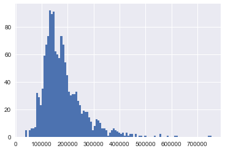

```python
plt.hist(train['SalePrice'],bins=100);
```

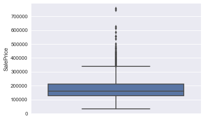

```python
sns.boxplot(train['SalePrice'],orient = "v");
```

From the above graph we can see that the data is skewed right so we will remove the top 5% to create a distribution of prices closer to normal

```python
train=train[train['SalePrice']<train['SalePrice'].quantile(.95)]
```

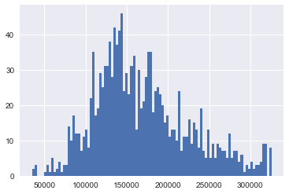

```python
plt.hist(train['SalePrice'],bins=100);
```

To make the distribution of prices closer to normal we will also take the log of the prices and use this as our dependent variable when fitting our model

```python
train['Log_prices']=train['SalePrice'].map(lambda x: np.log1p(x))
```

Now can check the house prices again and see the distribution looks closer to normal

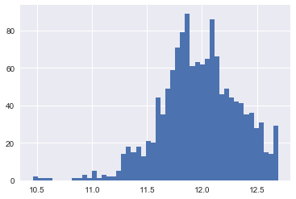

```python
plt.hist(train['Log_prices'],bins=50);
```

### Total Rooms

Now we will check the distribution of total rooms for outliers

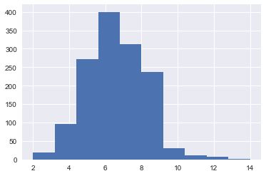

```python
plt.hist(train['TotRmsAbvGrd']);
```

From this we can see the distibution looks normal lets now use a box plot to see if there are any outliers

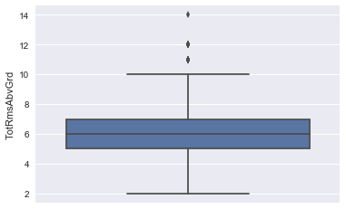

```python
sns.boxplot(train['TotRmsAbvGrd'],orient = "v");
```

from this we can see that there are some houses that have more than 10 rooms in them we will get rid of the top 2% of the data to remove the outliers

```python
train=train[train['TotRmsAbvGrd']<train['TotRmsAbvGrd'].quantile(.98)]
```

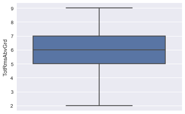

```python
sns.boxplot(train['TotRmsAbvGrd'],orient = "v");
```

Know we can see from the above graph that the outleirs are gone

### Combine the test and train data sets

```python
house=train.append(test)
```

Look at year sold max and min to see if the house prices might be affected by inflation i.e.( the range of sale dates is large and thus some of the older sale dates may be cheaper due to the year they were sold)

```python
print house['YrSold'].max()
print house['YrSold'].min()
```

```
2010
2006
```

Check the data set for duplicates

```python
# Check for Duplicates
print house['Id'].nunique()
print len (house['Id'])
```

```
2796
2796
```

## Step 3b: Fill in the null values

### Numeric Variables

1) BsmtFinSF1  
2) BsmtFinSF2  
3) BsmtFullBat  
4) BsmtHalfBat  
5) BsmtUnfSF  
6) GarageArea  
7) GarageCars  
8) LotFrontage  
9) MasVnrArea  
10) TotalBsmtSF

## Numeric Null Values

### Numeric basement null values

```python
for row in house['BsmtFinSF1']:
    if row == 0:
        zeros='True'

if zeros=='True':
    print 'There are 0s'
else:
    print 'There are no 0s'
```

```
There are 0s
```

Fill in the null values for the numeric basment variables with 0 because a null value means the house has no basement

```python
numerics=['BsmtFinSF1','BsmtFinSF2','BsmtFullBath','BsmtHalfBath','BsmtUnfSF']

for name in range(len(numerics)):
    house[numerics[name]].fillna(value=0,inplace=True)
```

Check to see if there are 0s in one of the total basement square feet columns

```python
for row in house['TotalBsmtSF']:
    if row == 0:
        zeros='True'

if zeros=='True':
    print 'There are 0s'
else:
    print 'There are no 0s'
```

```
There are 0s
```

```python
house['TotalBsmtSF'].fillna(value=house['TotalBsmtSF'].median(),inplace=True)
```

### Numeric Garage null values

Check to see if there are 0s in the Garage columns

```python
for row in house['GarageArea']:
    if row == 0:
        zeros='True'

if zeros=='True':
    print 'There are 0s'
else:
    print 'There are no 0s'
```

```
There are 0s
```

Because these columns have 0 the null values do not mean the house does not have a garage so we will fill in the null values with the median

```python
numerics=['GarageArea','GarageCars']

for name in range(len(numerics)):
    house[numerics[name]].fillna(value=house[numerics[name]].median(),inplace=True)
```

### Numeric lot frontage null values

Check to see if there are 0s in the lot frontage column

```python
for row in house['LotFrontage']:
    if row == 0:
        zeros='True'
if zeros=='True':
    print 'There are 0s'
else:
    print 'There are no 0s'
```

```
There are 0s
```

```python
house['LotFrontage'].fillna(0,inplace=True)
```

### MasVnrArea Null Values

Check to see if there are 0s in the MasVnrArea column

```python
for row in house['MasVnrArea']:
    if row == 0:
        zeros='True'
if zeros=='True':
    print 'There are 0s'
else:
    print 'There are no 0s'
```

```
There are 0s
```

There are 0s in this column so we will fill the null value in with the median

```python
house['MasVnrArea'].fillna(value=house['MasVnrArea'].median(),inplace=True)
```

## Categorical Null Values & Ordinal Variables

### Categorical basement null values

Look at the categories of each column to see if they have a category for no basement

```python
objs=['BsmtCond','BsmtExposure','BsmtFinType1','BsmtFinType2','BsmtQual']

for name in range(len(objs)):
    print objs[name]
    print house[objs[name]].unique()
```

```
BsmtCond
['TA' 'Gd' nan 'Fa' 'Po']
BsmtExposure
['No' 'Gd' 'Mn' 'Av' nan]
BsmtFinType1
['GLQ' 'ALQ' 'Unf' 'Rec' 'BLQ' nan 'LwQ']
BsmtFinType2
['Unf' 'BLQ' nan 'ALQ' 'Rec' 'LwQ' 'GLQ']
BsmtQual
['Gd' 'TA' 'Ex' nan 'Fa']
```

No column has a category for no basement so we will replace all the null values with no basement

```python
for name in range(len(objs)):
    house[objs[name]].fillna(value='no_basement',inplace=True)
```

### Categorical Electical Null Value

look at how many null values there are and the mode of the column

```python
print house['Electrical'].isnull().sum()
print house['Electrical'].mode()
```

```
1
0    SBrkr
dtype: object
```

Because there is only a hand full of null values use the mode to fill in the null values

```python
house['Electrical'].fillna(value=house['Electrical'].mode()[0],inplace=True)
```

### Categorical Exterior Null Value

Look at the categories in each of the exterior columns

```python
objs=['Exterior1st','Exterior2nd']

for name in range(len(objs)):
    print objs[name]
    print house[objs[name]].unique()
```

```
Exterior1st
['VinylSd' 'MetalSd' 'Wd Sdng' 'HdBoard' 'BrkFace' 'CemntBd' 'Plywood'
 'AsbShng' 'Stucco' 'WdShing' 'BrkComm' 'AsphShn' 'Stone' 'ImStucc'
 'CBlock' nan]
Exterior2nd
['VinylSd' 'MetalSd' 'Wd Shng' 'HdBoard' 'Plywood' 'Wd Sdng' 'CmentBd'
 'BrkFace' 'Stucco' 'AsbShng' 'Brk Cmn' 'ImStucc' 'AsphShn' 'Stone' 'Other'
 'CBlock' nan]
```

Notice how Exterior1st is missing other so fill in the null values in that column wiht Other and use the mode to fill in the null values in the Exterior2nd column

```python
house['Exterior1st'].fillna('Other',inplace=True)
house['Exterior2nd'].fillna(value=house['Exterior2nd'].mode()[0],inplace=True)
```

### Categorical Functional Null Value

Look at how many null values there are in the Functional column

```python
house['Functional'].isnull().sum()
```

```
2
```

We can use the mode to fill in the null values, because there are so few null values

```python
house['Functional'].fillna(value=house['Functional'].mode()[0],inplace=True)
```

### Categorical Garage Null Value

Check the garage categorical columns to see if they have a no garage category

```python
objs=['GarageCond','GarageFinish','GarageQual','GarageType']

for name in range(len(objs)):
    print objs[name]
    print house[objs[name]].unique()
```

```
GarageCond
['TA' 'Fa' nan 'Gd' 'Po' 'Ex']
GarageFinish
['RFn' 'Unf' 'Fin' nan]
GarageQual
['TA' 'Fa' 'Gd' nan 'Po' 'Ex']
GarageType
['Attchd' 'Detchd' 'CarPort' 'BuiltIn' nan 'Basment' '2Types']
```

There is no category for no garage so we will assume the null values mean the dwelling has no garage

```python
for name in range(len(objs)):
    house[objs[name]].fillna(value='No_Garage',inplace=True)
```

### Categorical KitchenQual Null Value

Check to see how many null values are in the column

```python
house['KitchenQual'].isnull().sum()
```

```
1
```

Use the mode to fill in the null values

```python
house['KitchenQual'].fillna(value=house['KitchenQual'].mode()[0],inplace=True)
```

### Categorical MSZoning Null Value

```python
house['MSZoning'].isnull().sum()
```

```
4
```

Use the mode to fill in the null values

```python
house['MSZoning'].fillna(value=house['MSZoning'].mode()[0],inplace=True)
```

### MasVnrType Null Values

```python
house['MasVnrType'].isnull().sum()
```

```
23
```

Use the mode to fill in the null values

```python
house['MasVnrType'].fillna(value=house['MasVnrType'].mode()[0],inplace=True)
```

### SaleType Null Value

```python
house['SaleType'].isnull().sum()
```

```
1
```

Use the mode to fill in the null values

```python
house['SaleType'].fillna(value=house['SaleType'].mode()[0],inplace=True)
```

### Utilities Null Value

```python
house['Utilities'].isnull().sum()
```

```
2
```

Use the mode to fill in the null values

```python
house['Utilities'].fillna(value=house['Utilities'].mode()[0],inplace=True)
```

### MiscFeature

Look at the categories in Misc Feature to see if there is a catagory for no misc features

```python
house['MiscFeature'].unique()
```

```
array([nan, 'Shed', 'Gar2', 'Othr'], dtype=object)
```

Fill in the null values with no misc feature

```python
house['MiscFeature'].fillna('no_misc_feature',inplace=True)
```

# Step 4: Modeling

## Step 4a: Feature Enginering

Create new columns/variables from the existing data that you think will help predict a more accurate house price

We already have data on how large the house is so we can flag the second floor then delete the first and second floor columns

```python
house['2ndflr/flag']=house['2ndFlrSF'].map(lambda x: 1 if x>0 else 0)
del house['2ndFlrSF']
del house['1stFlrSF']
```

We can use when the house was sold and the year it was remodeled to create a variable that shows how long ago the house was remodeled on the date of sale

```python
house['time_since_remodel']=(house['YrSold']-house['YearRemodAdd'])
```

Created a ratio that compares total lot frontage to total lot area

```python
house['lot_to_Frontage_ratio']=(house['LotFrontage']/house['LotArea'])
```

Ratio to compare total low quality square feet in the house to total square feet of the house

```python
house['low_qual_SF_ratio']=(house['LowQualFinSF']/house['GrLivArea'])

del house['LowQualFinSF']
```

We will find the ratio between unfinished basement square feet with total square feet of the basement

```python
house['unfsq_ratio']=(house['BsmtUnfSF']/house['TotalBsmtSF'])
# we have to fill null values created with 0 becuase when we divide my TotalBsmtSF if the house does not have a Bsmt we will be
# dividing by a zero creating a null number
house['unfsq_ratio'].fillna(0,inplace=True)
```

Instead of looking at the size of the pool we will flag the pool in order to tell the computer which houses have a pool vs those that do not regardless of pool size

```python
house['Pool/flag']=house['PoolArea'].map(lambda x: 1 if x>0 else 0)

del house['PoolArea']
```

We will do the same thing to the basement, deck, garage, fireplace, kitchens, and Tear remodel added columns

```python
house['Bsmt/flag']=house['TotalBsmtSF'].map(lambda x: 1 if x>0 else 0)
del house['TotalBsmtSF']
```

```python
house['Deck/flag']=house['WoodDeckSF'].map(lambda x: 1 if x>0 else 0)

del house['WoodDeckSF']
```

```python
house['Garage/flag']=house['GarageArea'].map(lambda x: 1 if x>0 else 0)

del house['GarageArea']
```

```python
house['Fireplace/flag']=house['Fireplaces'].map(lambda x: 1 if x>0 else 0)
del house['Fireplaces']
```

```python
house['Kitchen/flag']=house['KitchenAbvGr'].map(lambda x: 1 if x>0 else 0)
del house['KitchenAbvGr']
```

```python
house['MasVnrArea/flag']=house['MasVnrArea'].map(lambda x: 1 if x>0 else 0)
del house['MasVnrArea']
```

```python
house['YearRemodAdd']=house['YearRemodAdd'].map(lambda x: 1 if x>0 else 0)
```

## Step 4b: Combining Columns

Combine all the bathroom columns into one column

```python
# treat the half baths as .5 when adding the bathrooms
house['BsmtHalfBath']=house['BsmtHalfBath'].map(lambda x: x/2 if x>0 else 0)
house['HalfBath']=house['HalfBath'].map(lambda x: x/2 if x>0 else 0)

# sum up all the bathroom columns
house['bathrooms']=(house['BsmtFullBath']+house['HalfBath']+house['BsmtHalfBath']+house['FullBath'])

# delete all the bathroom columns used to find the sum
del house['BsmtFullBath']
del house['HalfBath']
del house['BsmtHalfBath']
del house['FullBath']

# feature engineer a bed to bath ratio note:(we have to add one to bathrooms for the dwellings that have 0 bathrooms)
house['Bed_to_bath_ratio']=(house['TotRmsAbvGrd']/(house['bathrooms']+1))
```

Combine all the porch columns into one column

```python
# Convert all the porch columns into a 1 or 0 indicating if they have or do not have a porch
house['3SsnPorch']=house['3SsnPorch'].map(lambda x: 1 if x>0 else 0)
house['EnclosedPorch']=house['EnclosedPorch'].map(lambda x: 1 if x>0 else 0)
house['OpenPorchSF']=house['OpenPorchSF'].map(lambda x: 1 if x>0 else 0)
house['ScreenPorch']=house['ScreenPorch'].map(lambda x: 1 if x>0 else 0)

# Sum up all the porch columns into one column then delete the columns you summed up
house['Porches']=(house['EnclosedPorch']+house['3SsnPorch']+house['OpenPorchSF']+house['ScreenPorch'])

del house['EnclosedPorch']
del house['3SsnPorch']
del house['OpenPorchSF']
del house['ScreenPorch']
```

## Step 4c: Variable Conversion

MSSubClass is stored as int convert it to a string so that when we create dummy variables it will be converted

```python
# MSSubClass
house['MSSubClass']=house['MSSubClass'].map(lambda x: str(x))
```

### Ordinal Variable conversion

For each ordinal variable we will assign a number value for each category using a dictionary this will give the categories an order and allow us to later convert them into ordinal variables

### Exterior Ordinal conversion

```python
exter_dict={'Ex':5, 'Gd':4, 'TA':3, 'Fa':2, 'Po':1}

for index, row in house.iterrows():
    cond=row['ExterCond']
    house.at[index,'ExterCond']=exter_dict[cond]

for index, row in house.iterrows():
    qual=row['ExterQual']
    house.at[index,'ExterQual']=exter_dict[qual]

house['Exteravg']=((house['ExterQual']+house['ExterCond'])/2)

del house['ExterCond']
del house['ExterQual']
```

### Garage Ordinal conversion

```python
Garage_dict={'Ex':5, 'Gd':4, 'TA':3, 'Fa':2, 'Po':1, 'NA':0, 'No_Garage':0}

for index, row in house.iterrows():
    cond=row['GarageCond']
    house.at[index,'GarageCond']=Garage_dict[cond]

for index, row in house.iterrows():
    qual=row['GarageQual']
    house.at[index,'GarageQual']=Garage_dict[qual]

house['Garageavg']=((house['GarageCond']+house['GarageQual'])/2)

house['Garageavg']=house['Garageavg'].map(lambda x: 0 if x>6 else x)

del house['GarageCond']
del house['GarageQual']
```

```python
GarageFinish_dict={'Fin':3,'RFn':2,'Unf':1,'No_Garage':0}

for index, row in house.iterrows():
    qual=row['GarageFinish']
    house.at[index,'GarageFinish']=GarageFinish_dict[qual]
```

### Overall Ordinal conversion

```python
house['Overall_avg']=((house['OverallCond']+house['OverallQual'])/2)

del house['OverallCond']
del house['OverallQual']
```

### Basement Ordinal conversion

```python
Bsmt_dict={'Ex':6, 'Gd':5, 'TA':4, 'Fa':3, 'Po':2, 'No':1, 'no_basement':0}

for index, row in house.iterrows():
    cond=row['BsmtCond']
    house.at[index,'BsmtCond']=Bsmt_dict[cond]

for index, row in house.iterrows():
    qual=row['BsmtQual']
    house.at[index,'BsmtQual']=Bsmt_dict[qual]

house['Bsmteavg']=((house['BsmtQual']+house['BsmtCond'])/2)

house['Bsmteavg']=house['Bsmteavg'].map(lambda x: 0 if x>6 else x)

del house['BsmtQual']
del house['BsmtCond']
```

```python
BsmtFinType_dict={'GLQ':7, 'ALQ':6, 'BLQ':5, 'Rec':4, 'LwQ':3, 'Unf':2, 'No':1, 'no_basement':0}

for index, row in house.iterrows():
    cond=row['BsmtFinType1']
    house.at[index,'BsmtFinType1']=BsmtFinType_dict[cond]

for index, row in house.iterrows():
    cond=row['BsmtFinType2']
    house.at[index,'BsmtFinType2']=BsmtFinType_dict[cond]

house['BsmtFinTypeavg']=((house['BsmtFinType1']+house['BsmtFinType2'])/2)

house['BsmtFinTypeavg']=house['BsmtFinTypeavg'].map(lambda x: 0 if x>6 else x)

del house['BsmtFinType1']
del house['BsmtFinType2']
```

### Kitchen Ordinal conversion

```python
Kitchen_dict={'Ex':5, 'Gd':4, 'TA':3, 'Fa':2, 'Po':1}

for index, row in house.iterrows():
    cond=row['KitchenQual']
    house.at[index,'KitchenQual']=Kitchen_dict[cond]
```

### Utilities Ordinal conversion

```python
Utilities_dict={'AllPub':4, 'NoSewr':3, 'NoSeWa':2, 'ELO':1}

for index, row in house.iterrows():
    cond=row['Utilities']
    house.at[index,'Utilities']=Utilities_dict[cond]
```

### Drive way Ordinal conversion

```python
PavedDrive_dict={'Y':3,'P':2, 'N':1}

for index, row in house.iterrows():
    cond=row['PavedDrive']
    house.at[index,'PavedDrive']=PavedDrive_dict[cond]
```

### Heating Ordinal conversion

```python
HeatingQC_dict={'Ex':5, 'Gd':4, 'TA':3, 'Fa':2, 'Po':1}

for index, row in house.iterrows():
    cond=row['HeatingQC']
    house.at[index,'HeatingQC']=HeatingQC_dict[cond]
```

### Functionality Ordinal conversion

```python
Functional_dict={'Typ':7, 'Min1':6, 'Min2':5, 'Mod':4, 'Maj1':3,'Maj2':2,'Sev':1,'Sal':0}

for index, row in house.iterrows():
    cond=row['Functional']
    house.at[index,'Functional']=Functional_dict[cond]
```

Now convert all the ordinal columns into data type category

```python
house['Overall_avg']=house['Overall_avg'].astype('category')
house['Bsmteavg']=house['Bsmteavg'].astype('category')
house['Garageavg']=house['Garageavg'].astype('category')
house['GarageFinish']=house['GarageFinish'].astype('category')
house['Exteravg']=house['Exteravg'].astype('category')
house['KitchenQual']=house['KitchenQual'].astype('category')
house['Utilities']=house['Utilities'].astype('category')
house['PavedDrive']=house['PavedDrive'].astype('category')
house['HeatingQC']=house['HeatingQC'].astype('category')
house['BsmtFinTypeavg']=house['BsmtFinTypeavg'].astype('category')
house['Porches']=house['Porches'].astype('category')
house['Functional']=house['Functional'].astype('category')
```

```python
del house['BsmtFinTypeavg']
del house['Bsmteavg']
del house['Garageavg']
```

```python
# store all the columns of the data frame in a list
cols=house.columns

# loop through the list and search for all the dtype category columns and append it to a new list
category=[]
for i in range(len(cols)):
    if house[cols[i]].dtype.name=='category':
        numerics.append(cols[i])

# use that new list to order the ordinal variables
for i in range(len(category)):
    house[category[i]].cat.as_ordered(inplace=True)
```

## Step 4d: Creating dummy variables

### Combining exterior dummy columns

Because exterior1st and exterior2nd have the same information stored in separate columns we should combine these columns or else when convert categorical variables to dummy variables the computer will treat these two columns as separate variables

```python
# store each column in its own data frame
exter1=house[['Exterior1st']]
exter2=house[['Exterior2nd']]
```

Use get dummies on each columns we want to combine

```python
ext1_dummy=pd.get_dummies(exter1,drop_first=True)
ext2_dummy=pd.get_dummies(exter2,drop_first=True)
```

Re name the coulumns so that they have the same name

```python
# store each column name in a list
oldnames1=ext1_dummy.columns
oldnames2=ext2_dummy.columns
# create a new list of the updated names you want to use to replace the old names
newnames=['AsphShn', 'BrkComm', 'BrkFace', 'CBlock', 'CemntBd', 'HdBoard', 'ImStucc',
 'MetalSd', 'Other', 'Plywood', 'Stone', 'Stucco', 'VinylSd', 'Wd Sdng',
 'WdShing']

# loop through each of the data frames and replace the old name list with the new name list at each column
for i in range(len(oldnames1)):
    ext1_dummy.rename(columns={oldnames1[i]: newnames[i]}, inplace=True)

for i in range(len(oldnames1)):
    ext2_dummy.rename(columns={oldnames2[i]: newnames[i]}, inplace=True)
```

Print the length of each data frame to ensure they are the same size before combining them

```python
print len(ext1_dummy)
print len(ext2_dummy)
cols=ext1_dummy.columns
```

```
2796
2796
```

Now add the columns together and assign the summed columns back to the original data frame

```python
for num in range(len(cols)):
    house[cols[num]]=(ext1_dummy[cols[num]]+ext2_dummy[cols[num]])
```

Finally delete the original columns so we do not convert them to dummy variables later

```python
del house['Exterior1st']
del house['Exterior2nd']
```

### Combining condition dummy columns

Now we repeat the same process for the condition columns

Store each column in its own data frame

```python
cond1=house[['Condition1']]
cond2=house[['Condition2']]
```

Convert the columns into dummy variables

```python
cond1_dummy=pd.get_dummies(cond1,drop_first=True)
cond2_dummy=pd.get_dummies(cond2,drop_first=True)
```

Re place the old names with new names the second data frame did not have as many columns because it did not have the same amount of categories as the first column did

```python
oldnames1=cond1_dummy.columns
oldnames2=cond2_dummy.columns
newnames1=['Feedr', 'Norm', 'PosA', 'PosN', 'RRAe', 'RRAn', 'RRNe', 'RRNn']
newnames2=['Feedr', 'Norm', 'PosA', 'PosN', 'RRAe', 'RRAn', 'RRNn']

for i in range(len(oldnames1)):
    cond1_dummy.rename(columns={oldnames1[i]: newnames1[i]}, inplace=True)

for i in range(len(oldnames2)):
    cond2_dummy.rename(columns={oldnames2[i]: newnames2[i]}, inplace=True)
```

Ensure the length of both data frames are equal before combining them

```python
print len(cond1_dummy)
print len(cond2_dummy)
cols=cond1_dummy.columns
```

```
2796
2796
```

Create a loop that will sum up the columns and assign the summed column back to the original data frame

This loop looks a little different then the one above because the number of columns do not match up so we must use a try and except parameter to ensure all the columns get assigned back to the original data frame

```python
for num in range(len(cols)):
    try:
        house[cols[num]]=(cond1_dummy[cols[num]]+cond2_dummy[cols[num]])
    except:
        house[cols[num]]=cond1_dummy[cols[num]]
```

Delete the original columns

```python
del house['Condition1']
del house['Condition2']
```

Delete columns that do not add value to the algorithm

```python
del house['MoSold']
del house['MiscVal']
del house['GarageFinish']
del house['MasVnrType']

del house['BsmtExposure']
del house['BsmtFinSF1']
del house['BsmtFinSF2']

del house['RoofStyle']
del house['YrSold']
```

Normalize all of the numeric data

```python
# store all the column names in a list
cols=house.columns

# loop through the list of column names and store any column with numeric values in a new list
numerics=[]
for i in range(len(cols)):
    if house[cols[i]].dtype.name=='int64':
        numerics.append(cols[i])
    elif house[cols[i]].dtype.name=='float64':
        numerics.append(cols[i])

# remove the descriptive and dependent variables from this list
numerics.remove('Id')
numerics.remove('Log_prices')
numerics.remove('SalePrice')

# for each column in the list normalize all the values by subtracting the min and dividing by the diffrence of the max and min
for i in range(len(numerics)):
    house[numerics[i]]=(house[numerics[i]]-house[numerics[i]].min())/(house[numerics[i]].max()-house[numerics[i]].min())
# fill in the null values that this creates with 0 (the null values are the min aka when you subtract the min from the min)
    house[numerics[i]].fillna(0,inplace=True)
```

### Dummy Variables

```python
# Store all the categorical columns (the columns with data type object) in a list
cols=house.columns

dummies=[]
for i in range(len(cols)):
    if house[cols[i]].dtype.name=='object':
        dummies.append(cols[i])
```

print out your list to make sure these are the columns you want to convert into dummy variables

```python
dummies
```

```
['BldgType',
 'CentralAir',
 'Electrical',
 'Foundation',
 'GarageType',
 'Heating',
 'HouseStyle',
 'LandContour',
 'LandSlope',
 'LotConfig',
 'LotShape',
 'MSSubClass',
 'MSZoning',
 'MiscFeature',
 'Neighborhood',
 'RoofMatl',
 'SaleCondition',
 'SaleType',
 'Street']
```

Convert all the columns stored in your list into dummy variables

```python
house_dummies=pd.get_dummies(house,drop_first=True,columns=dummies)
```

## Step 4e: Creating and fiting the model

Find the row in which you need to split the test and train data back into their original data frames

```python
print len(train), len(test), len(house)
```

```
1337 1459 2796
```

Split the combined data frame back into the train and test data frames

```python
NewTrain= house_dummies[:1337]
NewTest=house_dummies[1337:]
```

Delete the dependent and descriptive variables form the test dataset

```python
del NewTest['SalePrice']
del NewTest['Log_prices']
del NewTest['Id']
```

Import the necessary models and define your independent and dependent variables with x and y

After you defined your variables use train test split to randomly split the data for fitting

```python
import statsmodels.api as sm
from sklearn.cross_validation import train_test_split

x=NewTrain.drop(['Id','SalePrice','Log_prices'],axis=1)
y=NewTrain[['Log_prices']]
X = sm.add_constant(x)
X_train, X_test, y_train, y_test = train_test_split(x, y, test_size=.20, random_state=0)
```

Import and fit the models then use the fitted model to predict the log house prices

```python
from sklearn.linear_model import Ridge, Lasso
from sklearn.metrics import mean_squared_error,r2_score
from sklearn import linear_model
from sklearn.ensemble import GradientBoostingRegressor

priceridge= linear_model.Ridge()
priceridge.fit(X_train, y_train)
ridge=priceridge.predict(X_test)

priceLasso= linear_model.Lasso()
priceLasso.fit(X_train, y_train)
lasso=priceLasso.predict(X_test)

priceGBR= GradientBoostingRegressor()
priceGBR.fit(X_train, y_train)
GBR=priceGBR.predict(X_test)
```

# Step 5: Evaluation

print out the MSE and r2 score for each model then select the bet model to predict the test data set

```python
print 'Ridge'
print mean_squared_error(y_test, ridge)**.5
print r2_score(y_test, ridge)
```

```
Ridge
0.123795623662
0.861061407047
```

```python
print 'Lasso'
print mean_squared_error(y_test, lasso)**.5
print r2_score(y_test, lasso)
```

```
Lasso
0.332580393323
-0.00277984733161
```

```python
print 'GBR'
print mean_squared_error(y_test, GBR)**.5
print r2_score(y_test, GBR)
```

```
GBR
0.123935212116
0.86074790392
```

Use the choosen model to predict the house prices for the test data set take the reverse log of these prices and store the normal prices in a list

```python
Prices = priceridge.predict(NewTest)
Prices=np.expm1(Prices)
Prices
```

```
array([[ 112196.27485698],
       [ 150825.41686229],
       [ 177054.94685048],
       ...,
       [ 153843.37237488],
       [ 119932.17015978],
       [ 230278.53826198]])
```

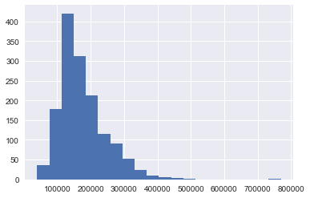

```python
plt.hist(Prices,bins=20);
```

Use the list of predicted house prices to create a data frame with house prices and corresponding house ID

Output this data frame to a csv file that will be used to submit to kaggle

```python
results= pd.DataFrame(columns=['Id','SalePrice'])
results['Id']= test['Id']
results['SalePrice']= Prices
results.to_csv('Price_results.csv',  index = False)
```